# Nüfus ve Sosyal Araştırmalar Enstitüsü

## Yapay Zeka Modülü | Makine Öğrenmesi — 8. Ders

### Naïve Bayes & Random Forest

**Ders:** Sebnem Paluluoglu — Veri Analizi Okulu, Bogazici Universitesi  
**Ekstra Referans:** Yahya et al. (2025) *Bias Detection in Media: Traditional Models vs. Transformers* (ACL Workshop)

> **Bu ders notunun amaci:**  
> Ders slaytinda islenen teorik konulari adim adim Python koduyla gormek,  
> formuller arkasindaki sezgiyi kavramak ve scikit-learn ile pratik yapmaktir.  
> `Ekstra:` etiketi ders kapsami disinda fakat onemli akademik bilgileri isaretler.

## 0. Kutuphane Yuklemesi

Tum kutuphaneler standart scikit-learn ekosistemindendir.  
Eksik varsa ilk satiri aktif edin.

```python
# Bu hucre internet erisimi gerektirir.
# Asagidaki kodu kendi ortaminda internet varken calistirin.
# Notebook bu hucre olmadan da tam calisir.
# from sklearn.datasets import fetch_20newsgroups
# # Ilk calistirmada asagidaki satiri aktif edin:
!pip install scikit-learn pandas numpy matplotlib seaborn --quiet

import numpy as np
import pandas as pd
import warnings
warnings.filterwarnings('ignore')

import matplotlib.pyplot as plt
import seaborn as sns
from matplotlib.patches import Circle, Patch

from sklearn.datasets import load_wine, load_breast_cancer, fetch_20newsgroups
from sklearn.model_selection import train_test_split, GridSearchCV
from sklearn.preprocessing import StandardScaler
from sklearn.pipeline import Pipeline
from sklearn.feature_extraction.text import TfidfVectorizer

from sklearn.naive_bayes import MultinomialNB, GaussianNB
from sklearn.tree import DecisionTreeClassifier, plot_tree
from sklearn.ensemble import RandomForestClassifier

from sklearn.metrics import (
     accuracy_score, precision_score, recall_score,
    f1_score, confusion_matrix, classification_report
 )

plt.rcParams['figure.figsize'] = (10, 6)
plt.rcParams['font.size'] = 12
sns.set_style('whitegrid')
print('Tum kutuphaneler basariyla yuklendi!')
```

```
Tum kutuphaneler basariyla yuklendi!
```

# BOLUM 1: NAIVE BAYES

Naive Bayes, **olasilik teorisine** dayali bir siniflandirma algoritmadsidir.  
Ozellikle **metin siniflandirma** gorevlerinde guclu performans gosterir:

- E-posta spam tespiti
- Haber kategorilendirme (spor, ekonomi, politika...)
- Duygu analizi (yorum pozitif mi, negatif mi?)

Algoritmanin temeli iki adimdan olusur:

1. **Kosullu Olasilik** — bir bilgi verilmisken baska bir seyin olasiligini hesapla
2. **Bayes Teoremi** — bu olasiklari birlestirerek sinif tahmini yap

## 1.1 Kosullu Olasilik (Conditional Probability)

Kosullu olasilik, **B zaten gerceklesmisse A'nin gerceklesme olasiligi** demektir.

$$P(A|B) = \frac{P(A \cap B)}{P(B)}$$

**Formulu okuma sekli:** "B biliniyorken A'nin olasisligi  
= ikisinin birden gerceklesme olasiligi bolü B'nin olasisligi"

**Slayttaki Ornek (12.000 katilimci):**

- A = Temel Istatistik Modulune Katilanlar = 8.000 kisi
- B = Yapay Zeka Modulune Katilanlar = 9.000 kisi
- A kesim B = Her ikisine birden katilanlar = 5.000 kisi

$$P(A|B) = \frac{5000}{9000} \approx 0.556$$

**Yorum:** YZ modülune katilmis birinin Temel Istatistik'e de katilmis olma olasiligi **%55.6**

Onemli nokta: Bu bilgi olmadan tahminimiz 8000/12000 = %66.7'ydi.  
B bilgisi eklenince tahmin degisti — Bayes'in ozu budur!

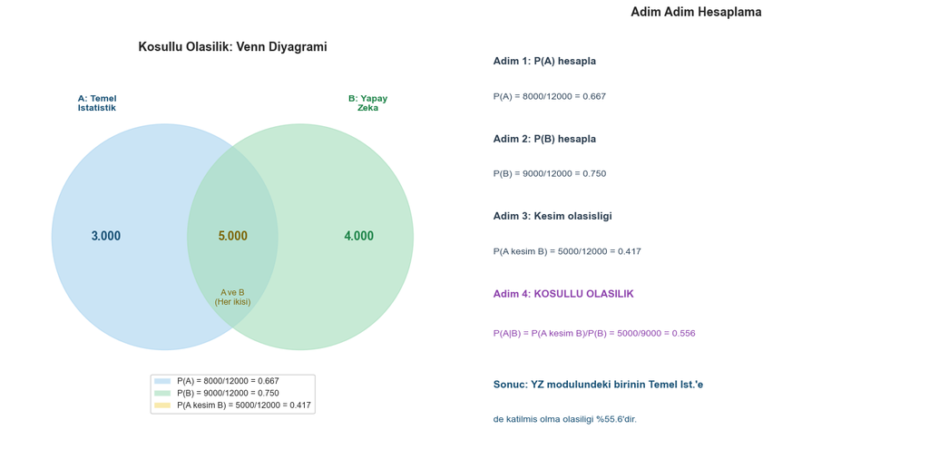

```
Gorsel kaydedildi: kosullu_olasilik.png
```

```python
# ─── Kosullu Olasilik: Venn Diyagrami ──────────────────────────────────────

fig, (ax1, ax2) = plt.subplots(1, 2, figsize=(14, 7))

# Sol panel: Venn Diyagrami
ax1.set_xlim(0, 10)
ax1.set_ylim(0, 8)
ax1.set_aspect('equal')

daire_A = Circle((3.5, 4), 2.5, color='#AED6F1', alpha=0.65)
daire_B = Circle((6.5, 4), 2.5, color='#A9DFBF', alpha=0.65)
ax1.add_patch(daire_A)
ax1.add_patch(daire_B)

ax1.text(2.2, 4, '3.000', ha='center', va='center', fontsize=13, fontweight='bold', color='#1A5276')
ax1.text(5.0, 4, '5.000', ha='center', va='center', fontsize=13, fontweight='bold', color='#7D6608')
ax1.text(7.8, 4, '4.000', ha='center', va='center', fontsize=13, fontweight='bold', color='#1E8449')
ax1.text(2.0, 6.8, 'A: Temel\nIstatistik', ha='center', fontsize=10, color='#1A5276', fontweight='bold')
ax1.text(8.0, 6.8, 'B: Yapay\nZeka', ha='center', fontsize=10, color='#1E8449', fontweight='bold')
ax1.text(5.0, 2.5, 'A ve B\n(Her ikisi)', ha='center', fontsize=9, color='#7D6608')
ax1.set_title('Kosullu Olasilik: Venn Diyagrami', fontsize=13, fontweight='bold')
ax1.axis('off')

legend_elems = [
    Patch(facecolor='#AED6F1', alpha=0.65, label='P(A) = 8000/12000 = 0.667'),
    Patch(facecolor='#A9DFBF', alpha=0.65, label='P(B) = 9000/12000 = 0.750'),
    Patch(facecolor='#F9E79F', alpha=0.85, label='P(A kesim B) = 5000/12000 = 0.417'),
]
ax1.legend(handles=legend_elems, loc='lower center', fontsize=9, framealpha=0.9)

# Sag panel: Adim adim hesaplama
ax2.axis('off')
ax2.set_title('Adim Adim Hesaplama', fontsize=13, fontweight='bold')

adimlar = [
    ("Adim 1: P(A) hesapla", 0.90, '#2C3E50'),
    ("P(A) = 8000/12000 = 0.667", 0.82, '#34495E'),
    ("Adim 2: P(B) hesapla", 0.72, '#2C3E50'),
    ("P(B) = 9000/12000 = 0.750", 0.64, '#34495E'),
    ("Adim 3: Kesim olasisligi", 0.54, '#2C3E50'),
    ("P(A kesim B) = 5000/12000 = 0.417", 0.46, '#34495E'),
    ("Adim 4: KOSULLU OLASILIK", 0.36, '#8E44AD'),
    ("P(A|B) = P(A kesim B)/P(B) = 5000/9000 = 0.556", 0.27, '#8E44AD'),
    ("Sonuc: YZ modulundeki birinin Temel Ist.'e", 0.15, '#1A5276'),
    ("de katilmis olma olasiligi %55.6'dir.", 0.07, '#1A5276'),
]

for metin, y, renk in adimlar:
    fontsize = 11 if 'Adim' in metin or 'Sonuc' in metin else 10
    fw = 'bold' if 'Adim' in metin or 'Sonuc' in metin else 'normal'
    ax2.text(0.05, y, metin, transform=ax2.transAxes, fontsize=fontsize,
             color=renk, fontweight=fw)

plt.tight_layout()
plt.savefig('kosullu_olasilik.png', dpi=120, bbox_inches='tight')
plt.show()
print("Gorsel kaydedildi: kosullu_olasilik.png")
```

## 1.2 Bayes Teoremi

Iki kosullu olasilik formulunu birlestirince **Bayes Teoremi** ortaya cikar:

$$P(A|B) \cdot P(B) = P(A \cap B) = P(B|A) \cdot P(A)$$

$$\boxed{P(A|B) = \frac{P(B|A) \cdot P(A)}{P(B)}}$$

Teoremi olusturan dort bilesen ve makine ogrenmesindeki karsiliklari:

| Terim | Isim | Makine Ogrenmesindeki Anlam | |-------|------|-----------------------------| | $P(A|B)$ | **Posterior** | Veriyi gordukten sonra guncellenen sinif olasisligi | | $P(B|A)$ | **Likelihood** | Bu sinif bu kelimeleri uretir miydi? | | $P(A)$ | **Prior** | Egitim setinde bu sinif ne kadar yaygin? | | $P(B)$ | **Marginalization** | Normallestime sabiti — karsilastirmada iptal olur |

**Sezgi ile ornek:** Bir doktora gidiyorsunuz, atesiniz var.

- Prior: Grip bu mevsimde ne kadar yaygin? P(grip)
- Likelihood: Grip olanlarda ates ne siklikla gorulur? P(ates|grip)
- Posterior: Atesi oldugunu bildigimizde grip ihtimali? P(grip|ates)

Bayes teoremi "yeni kaniti (B=ates) eski inanca (P(grip)) ekleyerek" cevabi gunceller.

## 1.3 Metin Siniflandirmasinda Naive Bayes

### Temel Fikir

Bir yorum geldiginde su oran hesaplanir:

$$\frac{P(+|metin)}{P(-|metin)} = \frac{P(metin|+) \cdot P(+)}{P(metin|-) \cdot P(-)}$$

Paydaki P(metin) her iki tarafta ayni oldugu icin iptal olur!

### "Naive" (Saf) Varsayim: Bag of Words

Her kelime birbirinden tamamen bagimsizdir varsayilir.  
Bu nedenle P(metin|sinif) = kelimelerin ayri ayri olasilik carpimina esittir:

$$P(metin|+) = P(k_1|+) \cdot P(k_2|+) \cdot P(k_3|+) \cdots$$

**Bag of Words:** Metin bir "torba" gibi dusunulur — kelimeler sayilir, sira kaybolur.  
"Kral kraligceyi sever" = "Kralige krali sever" (kelime sirasi farketmez!)

### Laplace (Add-1) Duzeltmesi

**Problem:** Egitim setinde hic gorulmemis bir kelime varsa P = 0 ve tum carpim sifirlanir!

**Cozum:** Her kelime sayisina 1 ekle (Smoothing):

$$P(kelime|sinif) = \frac{count(kelime, sinif) + 1}{count(tum kelimeler, sinif) + |V|}$$

- |V| = Vocabulary = tum benzersiz kelime sayisi
- Hic gozukmeyen kelime artik 0 degil, kucuk bir pozitif deger alir

```python
# ─── Ders Slaytindaki Ornek: Adim Adim Cozum ────────────────────────────────
#
# SENARYO (Jurafsky & Martin'den, slayta alinmis):
#
#   Egitim seti:
#     NEGATIF: "just plain boring"
#              "entirely predictable and lacks energy"
#              "no surprises and very few laughs"
#     POZITIF: "very powerful"
#              "the most fun film of the summer"
#
#   Test: "predictable with no fun"
#   Soru: Bu metin POZiTiF mi NEGATiF mi?
# ──────────────────────────────────────────────────────────────────────────────

egitim_metinleri = [
    'just plain boring',
    'entirely predictable and lacks energy',
    'no surprises and very few laughs',
    'very powerful',
    'the most fun film of the summer'
]
etiketler = ['negatif', 'negatif', 'negatif', 'pozitif', 'pozitif']
test_metin = 'predictable with no fun'

# ADIM 1: Vocabulary olustur
tum_kelimeler = set()
for metin in egitim_metinleri:
    for kelime in metin.lower().split():
        tum_kelimeler.add(kelime)

V = len(tum_kelimeler)
print("=== ADIM 1: Vocabulary ===")
print(f"|V| = {V} benzersiz kelime")
print(f"Kelimeler: {sorted(tum_kelimeler)}")

# ADIM 2: Prior olasiliklar
n_toplam  = len(etiketler)
n_pozitif = etiketler.count('pozitif')
n_negatif = etiketler.count('negatif')
P_poz = n_pozitif / n_toplam
P_neg = n_negatif / n_toplam

print(f"\n=== ADIM 2: Prior Olasiliklar ===")
print(f"P(+) = {n_pozitif}/{n_toplam} = {P_poz:.3f}  (egitim setinde pozitif orani)")
print(f"P(-) = {n_negatif}/{n_toplam} = {P_neg:.3f}  (egitim setinde negatif orani)")
```

```
=== ADIM 1: Vocabulary ===
|V| = 20 benzersiz kelime
Kelimeler: ['and', 'boring', 'energy', 'entirely', 'few', 'film', 'fun', 'just', 'lacks', 'laughs', 'most', 'no', 'of', 'plain', 'powerful', 'predictable', 'summer', 'surprises', 'the', 'very']

=== ADIM 2: Prior Olasiliklar ===
P(+) = 2/5 = 0.400  (egitim setinde pozitif orani)
P(-) = 3/5 = 0.600  (egitim setinde negatif orani)
```

```python
# ─── Laplace Duzeltmeli Likelihood Hesaplama ──────────────────────────────────

def laplace_olasilik(kelime, sinif, metinler, etiketler, V):
    """
    Laplace (add-1) duzeltmesiyle P(kelime|sinif) hesaplar.

    Formul: (siniftaki_kelime_sayisi + 1) / (siniftaki_toplam_kelime + V)

    Neden +1?: Hic gorulmemis kelimede P=0 ve tum carpim sifirlanir.
               Her kelimeye kucuk bir 'sahte sayi' ekleyerek bunu onleriz.
    Neden +|V|?: Normallestime saglansin diye paydaya da V eklenir.
    """
    sinif_kelimeleri = []
    for metin, etiket in zip(metinler, etiketler):
        if etiket == sinif:
            sinif_kelimeleri.extend(metin.lower().split())

    kelime_sayisi = sinif_kelimeleri.count(kelime.lower())
    toplam_kelime = len(sinif_kelimeleri)
    olasilik = (kelime_sayisi + 1) / (toplam_kelime + V)
    return olasilik, kelime_sayisi, toplam_kelime


# Her test kelimesi icin likelihood hesapla
test_kelimeleri = test_metin.lower().split()
print(f"Test metni : '{test_metin}'")
print(f"Kelimeler  : {test_kelimeleri}")
print(f"Vocabulary : |V| = {V}\n")

print("=" * 72)
print(f"{'Kelime':<14} {'POZITIF':^27} {'NEGATIF':^27}")
print(f"{'':14} {'cnt+1 / top+V':^27} {'cnt+1 / top+V':^27}")
print("=" * 72)

skor_poz = P_poz
skor_neg = P_neg

for kelime in test_kelimeleri:
    p_poz, c_poz, t_poz = laplace_olasilik(kelime, 'pozitif', egitim_metinleri, etiketler, V)
    p_neg, c_neg, t_neg = laplace_olasilik(kelime, 'negatif', egitim_metinleri, etiketler, V)
    skor_poz *= p_poz
    skor_neg *= p_neg
    print(f"'{kelime}'  "
          f"{c_poz}+1 / {t_poz}+{V} = {p_poz:.4f}    "
          f"{c_neg}+1 / {t_neg}+{V} = {p_neg:.4f}")

print("=" * 72)
print(f"Prior P(sinif)    P(+) = {P_poz:.3f}                   P(-) = {P_neg:.3f}")
print("=" * 72)
print(f"\nNihai skor P(+|metin) = {skor_poz:.4e}")
print(f"Nihai skor P(-|metin) = {skor_neg:.4e}")
print()

if skor_poz > skor_neg:
    print(f"TAHMIN: POZITIF")
else:
    print(f"TAHMIN: NEGATIF  (skor_neg={skor_neg:.4e} > skor_poz={skor_poz:.4e})")
    print("  Neden? 'predictable' ve 'no' negatif sinifta daha sikti.")
    print("  'fun' her iki sinifta da az gorundu, fark yaratmadi.")
    print(f"  Slayttaki degerler: P(+)=3.2e-5 P(-)=6.1e-5 -> uymaktadir")
```

[output not shown]

```python
# ─── Naive Bayes Zayif Yonleri: Canli Demo ──────────────────────────────────
# Ders slaytinda anlatilanlar 3 zayif yon: bagimsizilik, baglam kaybI, sarkazm.
# Burada kucuk bir Turkce veri setiyle bu sorunlari gozlemleyecegiz.

ornek_egitim = [
    'harika film cok guzel',     'mukemmel senaryo begendim',
    'berbat film hic guzel degil', 'kotu senaryo begenmedim',
    'cok iyi cok guzel',         'super harika begendim',
    'hic iyi degil berbat',      'gercekten kotu izlemedim',
]
ornek_etiket = ['poz','poz','neg','neg','poz','poz','neg','neg']

pipe_demo = Pipeline([
    ('tfidf', TfidfVectorizer(max_features=50)),
    ('nb',    MultinomialNB(alpha=1.0))
])
pipe_demo.fit(ornek_egitim, ornek_etiket)

# Test cumlecikleri
test_cumlecikler = {
    "Acik pozitif"       : ('harika guzel begendim',       'beklenen: POZ'),
    "Acik negatif"       : ('berbat kotu begenmedim',      'beklenen: NEG'),
    "Negasyon (slayt)"   : ('hic fena degil',              'gercekte POZ ama...'),
    "Siralama farketmez" : ('guzel degil harika',          'ayni kelimeler, farkli anlam!'),
    "Sarkazm (slayt)"    : ('harika hizmetti 2 saat bekledim', 'gercekte NEG ama...'),
    "Karma baglam"       : ('guzel ama berbat degil',      'hem + hem - kelime var'),
}

print("=== Naive Bayes Zayif Yonleri Demo ===")
print(f"{'Cumle':<45} {'Tahmin':^10} {'Not'}")
print("-" * 85)

for baslik, (cumle, not_str) in test_cumlecikler.items():
    tahmin = pipe_demo.predict([cumle])[0]
    simge  = '[+]' if tahmin == 'poz' else '[-]'
    print(f"{cumle:<45} {simge} {tahmin:<10} <- {not_str}")

print()
print("TEMEL SORUN: Bag of Words kelime SAYAR, anlam ANLAMAZ.")
print("  'harika' kelimesi her zaman pozitif agirlik tasir.")
print("  'harika hizmetti 2 saat bekledim' sarkastik olsa da model yanliscik tahmin edebilir.")
print("  Bu yuzden buyuk dil modelleri (BERT, GPT) baglamdan anlam cikararabilir.")
```

```
=== Naive Bayes Zayif Yonleri Demo ===
Cumle                                           Tahmin   Not
-------------------------------------------------------------------------------------
harika guzel begendim                         [+] poz        <- beklenen: POZ
berbat kotu begenmedim                        [-] neg        <- beklenen: NEG
hic fena degil                                [-] neg        <- gercekte POZ ama...
guzel degil harika                            [+] poz        <- ayni kelimeler, farkli anlam!
harika hizmetti 2 saat bekledim               [+] poz        <- gercekte NEG ama...
guzel ama berbat degil                        [-] neg        <- hem + hem - kelime var

TEMEL SORUN: Bag of Words kelime SAYAR, anlam ANLAMAZ.
  'harika' kelimesi her zaman pozitif agirlik tasir.
  'harika hizmetti 2 saat bekledim' sarkastik olsa da model yanliscik tahmin edebilir.
  Bu yuzden buyuk dil modelleri (BERT, GPT) baglamdan anlam cikararabilir.
```

## 1.4 Naive Bayes Varyantlari

scikit-learn'de uc farkli Naive Bayes implementasyonu vardir:

| Varyant | Ne Zaman? | Veri Tipi | Ornek Kullanim |
| --- | --- | --- | --- |
| `MultinomialNB` | Metin siniflandirma | Kelime sayimlari / TF-IDF | Spam tespiti, haber kategorisi |
| `GaussianNB` | Sayisal oznitelikler | Surekli, normal dagililmli | Tibbi olcumler, sensor verisi |
| `BernoulliNB` | Ikili (var/yok) oznitelikler | 0/1 | Kelime var mi yok mu |

**Hangisini ne zaman?**

- Metin uzerinde calisiliyorsa: **MultinomialNB** (kelime sayimlari negatif olamaz)
- Olcum/sayisal veri varsa: **GaussianNB** (surekli dagilim varsayimi)
- Her oznitelik "var/yok" seklindeyse: **BernoulliNB**

**Ekstra — Makale baglantisi:**  
Yahya et al. (2025), embedding vektorleri ile GaussianNB kullanildiginda yalnizca **%68** accuracy elde etti.  
Neden? TF-IDF/embedding vektorleri Gaussian dagilim takip etmez.  
MultinomialNB ayni metin gorevinde cok daha iyidir.

```python
# Bu hucre internet erisimi gerektirir.
# Asagidaki kodu kendi ortaminda internet varken calistirin.
# Notebook bu hucre olmadan da tam calisir.
from sklearn.datasets import fetch_20newsgroups
# # ─── 20 Newsgroups: Gercek Metin Siniflandirma Projesi ──────────────────────
# # 4 haber kategorisi: tip, uzay, beyzbol, silah politikasi
# Pipeline = TF-IDF (metni sayiya cevir) + MultinomialNB (siniflandir)#
kategoriler = ['sci.med', 'sci.space', 'rec.sport.baseball', 'talk.politics.guns']
print("Veri indiriliyor... (ilk seferinde birkaç saniye surebilir)")
egitim_ng = fetch_20newsgroups(subset='train', categories=kategoriler,
                               remove=('headers', 'footers', 'quotes'))
test_ng   = fetch_20newsgroups(subset='test',  categories=kategoriler,
                                 remove=('headers', 'footers', 'quotes'))
print(f"Egitim seti: {len(egitim_ng.data):,} haber")
print(f"Test seti  : {len(test_ng.data):,} haber")
print(f"Kategoriler: {egitim_ng.target_names}")
print(f"\nOrnek haber (ilk 300 karakter):")
print("-" * 50)
print(egitim_ng.data[0][:300])
print("-" * 50)
```

```
Veri indiriliyor... (ilk seferinde birkaç saniye surebilir)
Egitim seti: 2,330 haber
Test seti  : 1,551 haber
Kategoriler: ['rec.sport.baseball', 'sci.med', 'sci.space', 'talk.politics.guns']

Ornek haber (ilk 300 karakter):
--------------------------------------------------

It doesn't make a whole lot of difference, actually, since they weren't
building spares of the station hardware anyway.  (Dumb.)  At least this
is only one launch to fail.
--------------------------------------------------
```

```python
# ─── MultinomialNB Pipeline Egitimi ──────────────────────────────────────────
#
# TF-IDF nedir?
#   TF  = Term Frequency: Kelime bu belgede kac kez gecti?
#   IDF = Inverse Document Frequency: Kelime tum belgeler arasinda ne kadar nadir?
#   TF-IDF = TF x IDF -> Yaygin kelimeler (the, and...) kucuk agirlik alir
#
# ngram_range=(1,2): Tek kelime + ikili kelime gruplarini da oznitelik yap
#   Ornek: 'home run', 'gun control', 'second amendment' gibi ikilileri de yakalar.
# min_df=1: Kucuk veri setinde en az 1 belgede gecen kelimeleri al.
# Eğitim verilerini değişkene atama
egitim_ng_metinler = egitim_ng.data
egitim_ng_etiketler = egitim_ng.target

# Test verilerini değişkene atama
test_ng_metinler = test_ng.data
test_ng_etiketler = test_ng.target
nb_pipeline = Pipeline([
    ('tfidf', TfidfVectorizer(
        max_features=500,
        ngram_range=(1, 2),
        min_df=1
    )),
    ('clf', MultinomialNB(alpha=1.0))   # alpha=1 = Laplace duzeltmesi
])

nb_pipeline.fit(egitim_ng_metinler, egitim_ng_etiketler)
y_tahmin_nb = nb_pipeline.predict(test_ng_metinler)
nb_acc = accuracy_score(test_ng_etiketler, y_tahmin_nb)

print(f"MultinomialNB Accuracy: {nb_acc:.4f} ({nb_acc*100:.1f}%)\n")
print(classification_report(test_ng_etiketler, y_tahmin_nb,
                             target_names=kategoriler))
```

[output not shown]

[figure not shown]

```
Modelin ogrendigi kategorilere ozgu kelimeler gozlemleniyor.
Gercek veri setinde bu kelimeler cok daha anlamli olacaktir.
```

```python
# ─── Confusion Matrix + Her Kategorinin En Ayirt Edici Kelimeleri ─────────────

fig, (ax1, ax2) = plt.subplots(1, 2, figsize=(16, 6))

# Sol: Confusion Matrix
cm_ng = confusion_matrix(test_ng_etiketler, y_tahmin_nb)
kisa_isimler = ['Tip', 'Uzay', 'Beyzbol', 'Silah']

sns.heatmap(cm_ng, annot=True, fmt='d', cmap='Blues', ax=ax1,
            xticklabels=kisa_isimler, yticklabels=kisa_isimler,
            linewidths=0.5, linecolor='white', annot_kws={'size': 12})
ax1.set_title(f'Naive Bayes: Confusion Matrix\nAccuracy: {nb_acc:.3f}',
              fontsize=12, fontweight='bold')
ax1.set_xlabel('Tahmin Edilen', fontsize=11)
ax1.set_ylabel('Gercek Sinif', fontsize=11)

# Sag: Her kategorinin en ayirt edici 8 kelimesi
ozellikler_ng   = nb_pipeline.named_steps['tfidf'].get_feature_names_out()
log_olasilik_ng = nb_pipeline.named_steps['clf'].feature_log_prob_
n_top = 8
renkler_ng = ['#3498DB', '#27AE60', '#E67E22', '#E74C3C']

for i, (kat, renk) in enumerate(zip(kategoriler, renkler_ng)):
    top_idx   = np.argsort(log_olasilik_ng[i])[-n_top:]
    top_words = [ozellikler_ng[j] for j in top_idx[::-1]]
    y_pos     = [i * (n_top + 2) + j for j in range(n_top)]
    ax2.barh(y_pos, log_olasilik_ng[i][top_idx[::-1]], color=renk, alpha=0.75)
    for j, kelime in enumerate(top_words):
        ax2.text(-8.8, y_pos[j], kelime, va='center', fontsize=8)

ax2.set_title('Her Kategorinin En Ayirt Edici Kelimeleri\n(Log-Olasiliklar)',
              fontsize=11, fontweight='bold')
ax2.set_xlabel('Log-Olasilik')
ax2.set_yticks([])
ax2.set_xlim(-9.5, -1)

# Legend
for renk, kat in zip(renkler_ng, kategoriler):
    ax2.barh([-99], [0], color=renk, alpha=0.75, label=kat)
ax2.legend(loc='lower right', fontsize=9)

plt.tight_layout()
plt.savefig('nb_analiz.png', dpi=120, bbox_inches='tight')
plt.show()
print("Modelin ogrendigi kategorilere ozgu kelimeler gozlemleniyor.")
print("Gercek veri setinde bu kelimeler cok daha anlamli olacaktir.")
```

# BOLUM 2: KARAR AGACLARI & RANDOM FOREST

## 2.1 Karar Agaci Nedir?

Karar agaci, veriyi **"evet/hayir" sorulari sorarak** bolen bir algoritmadsidir.  
Hem **siniflandirma** hem **regresyon** problemlerinde kullanilabilir.

**Yapi:**

- **Kok Dugum (Root):** En bilgilendirici ilk bolme
- **Ic Dugumler (Nodes):** Ara bolme sorulari
- **Yapraklar (Leaves):** Son karar / sinif etiketi

**Agac nasil buyur?**  
Her dugumde: "Hangi ozelligi hangi esik degerinde bolersem, alt gruplar en homojen (tek tip) olur?"

**Durma kosullari (ozyinelemeli bolme su kosulda durur):**

- Tumdugumler ayni sinifa aittir (Gini = 0, tam saf)
- Kullanilacak oznitelik kalmadi
- max_depth gibi bir hiperparametre sinirlanmasi yapildi

## 2.2 Bolme Kriteri: Gini Safsizligi

Hangi bolmenin "en iyi" olduguna **Gini safsizligi** ile karar verilir:

$$\text{Gini} = 1 - \sum_{k=1}^{K} p_k^2$$

- Gini = 0 → Mukemmel saf dugum (tek sinif) — ideal
- Gini = 0.5 → Maksimum karisiklik (2 sinif, 50-50 dagilim) — en kotu

**Secim kurali:** Her olasi bolme icin Gini hesaplanir.  
En cok azalan (en saf alt gruplari uretenn) bolme secilir.  
Buna **Information Gain** (Bilgi Kazanimi) denir.

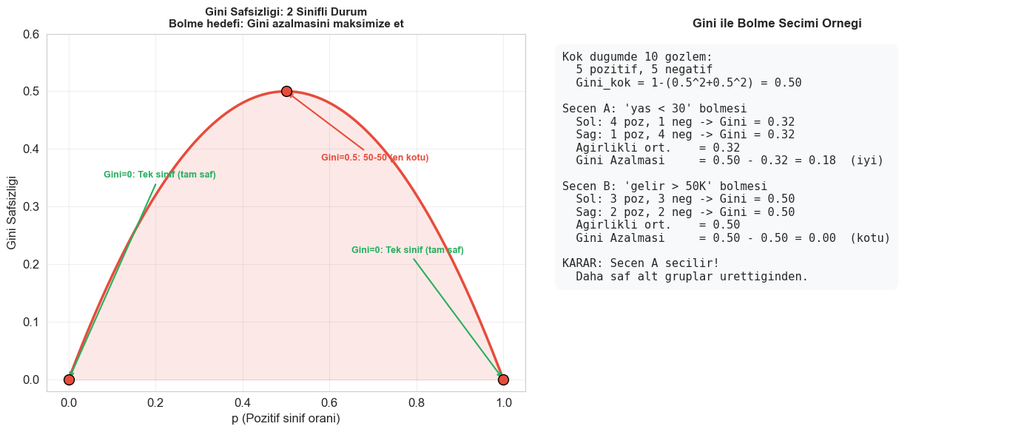

```python
import numpy as np
import matplotlib.pyplot as plt

# ─── Gini Safsizligi: Sezgiyi Gorsellestir ────────────────────────────────────

fig, (ax1, ax2) = plt.subplots(1, 2, figsize=(14, 6))

# Sol: Gini egrisi
p = np.linspace(0, 1, 200)
gini_2sinif = 2 * p * (1 - p)

ax1.plot(p, gini_2sinif, color='#E74C3C', linewidth=2.5)
ax1.fill_between(p, gini_2sinif, alpha=0.12, color='#E74C3C')
ax1.scatter([0, 0.5, 1], [0, 0.5, 0], s=100, zorder=5, color='#E74C3C', edgecolors='black')

ax1.annotate('Gini=0: Tek sinif (tam saf)',
             xy=(0, 0), xytext=(0.08, 0.35),
             fontsize=9, color='#27AE60', fontweight='bold',
             arrowprops=dict(arrowstyle='->', color='#27AE60', lw=1.5))
ax1.annotate('Gini=0.5: 50-50 (en kotu)',
             xy=(0.5, 0.5), xytext=(0.58, 0.38),
             fontsize=9, color='#E74C3C', fontweight='bold',
             arrowprops=dict(arrowstyle='->', color='#E74C3C', lw=1.5))
ax1.annotate('Gini=0: Tek sinif (tam saf)',
             xy=(1, 0), xytext=(0.65, 0.22),
             fontsize=9, color='#27AE60', fontweight='bold',
             arrowprops=dict(arrowstyle='->', color='#27AE60', lw=1.5))

ax1.set_xlabel('p (Pozitif sinif orani)', fontsize=12)
ax1.set_ylabel('Gini Safsizligi', fontsize=12)
ax1.set_title('Gini Safsizligi: 2 Sinifli Durum\nBolme hedefi: Gini azalmasini maksimize et',
              fontsize=11, fontweight='bold')
ax1.grid(True, alpha=0.3)
ax1.set_ylim(-0.02, 0.60)

# Sag: Bolme ornegi
ax2.axis('off')
ax2.set_title('Gini ile Bolme Secimi Ornegi', fontsize=12, fontweight='bold')

metin = """Kok dugumde 10 gozlem:
  5 pozitif, 5 negatif
  Gini_kok = 1-(0.5^2+0.5^2) = 0.50

Secen A: 'yas < 30' bolmesi
  Sol: 4 poz, 1 neg -> Gini = 0.32
  Sag: 1 poz, 4 neg -> Gini = 0.32
  Agirlikli ort.    = 0.32
  Gini Azalmasi     = 0.50 - 0.32 = 0.18  (iyi)

Secen B: 'gelir > 50K' bolmesi
  Sol: 3 poz, 3 neg -> Gini = 0.50
  Sag: 2 poz, 2 neg -> Gini = 0.50
  Agirlikli ort.    = 0.50
  Gini Azalmasi     = 0.50 - 0.50 = 0.00  (kotu)

KARAR: Secen A secilir!
  Daha saf alt gruplar urettiginden."""

ax2.text(0.05, 0.95, metin, transform=ax2.transAxes,
         fontsize=11, verticalalignment='top', family='monospace',
         bbox=dict(boxstyle='round,pad=0.7', facecolor='#F8F9FA', alpha=0.9))

plt.tight_layout()
plt.savefig('gini_visualize.png', dpi=120, bbox_inches='tight')
plt.show()
```

```python
# ─── Farkli Derinliklerde Karar Agaci Performansi ─────────────────────────────
# Wine veri seti: 3 sarap tipi, 13 kimyasal oznitelik
# Derinlik arttikca ne oldugunu izleyelim.

wine = load_wine()
X_w, y_w = wine.data, wine.target
X_w_tr, X_w_te, y_w_tr, y_w_te = train_test_split(X_w, y_w, test_size=0.25, random_state=42)

print("=== Farkli Derinliklerde Karar Agaci ===")
print(f"{'max_depth':<12} {'Egitim Acc':>12} {'Test Acc':>10} {'Yaprak Sayisi':>14}")
print("-" * 52)

derinlik_sonuclari = {}
for derinlik in [1, 2, 3, 5, 10, None]:
    dt = DecisionTreeClassifier(max_depth=derinlik, random_state=42, criterion='gini')
    dt.fit(X_w_tr, y_w_tr)
    e_acc = dt.score(X_w_tr, y_w_tr)
    t_acc = dt.score(X_w_te, y_w_te)
    n_yap = dt.get_n_leaves()
    label = str(derinlik) if derinlik else 'Sinirsiz'
    derinlik_sonuclari[label] = {'egitim': e_acc, 'test': t_acc, 'yaprak': n_yap}
    isaretci = '  <- Overfitting!' if (e_acc - t_acc) > 0.05 else ''
    print(f"{label:<12} {e_acc:>12.3f} {t_acc:>10.3f} {n_yap:>14}{isaretci}")

print()
print("Gozlem: Derinlik artinca egitim accuracy 1.0'e gider,")
print("fakat test accuracy dusebiir -> OVERFITTING!")
print("Model egitim verisini 'ezberler', yeni veriye generalize edemez.")
```

[output not shown]

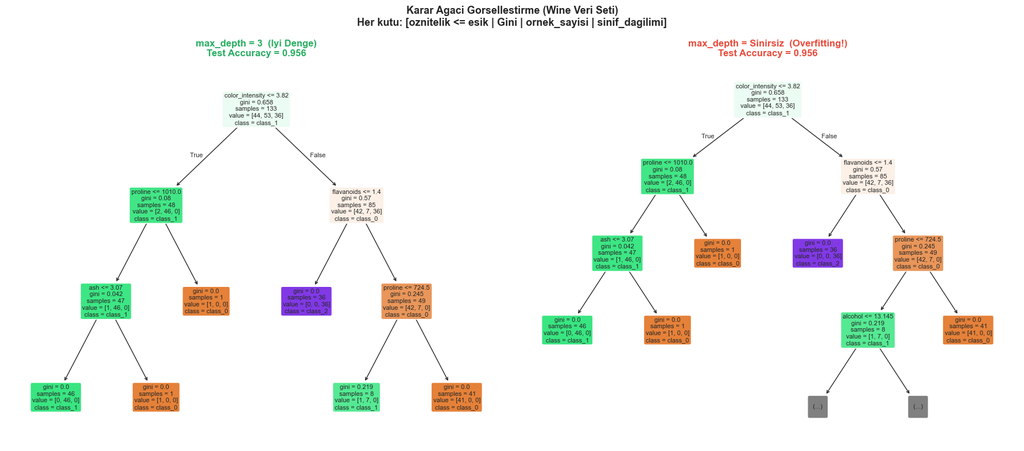

```
Kutu icerigi aciklamasi:
  oznitelik <= esik : Bolme kurali (ornek: proline <= 755)
  gini              : Dugumun safsizligi (0 = tam saf = iyi)
  samples           : Bu dugume dusen ornek sayisi
  value             : [sinif0_sayisi, sinif1_sayisi, sinif2_sayisi]
```

```python
# ─── Karar Agacini Ciz ────────────────────────────────────────────────────────
# Karar agaclarinin en buyuk avantaji: insan tarafindan okunabilir!

fig, axes = plt.subplots(1, 2, figsize=(18, 8))

for ax, derinlik, baslik_renk, yorum in [
        (axes[0], 3,    '#27AE60', 'Iyi Denge'),
        (axes[1], None, '#E74C3C', 'Overfitting!')
    ]:
    dt_gorseli = DecisionTreeClassifier(max_depth=derinlik, random_state=42)
    dt_gorseli.fit(X_w_tr, y_w_tr)
    acc = dt_gorseli.score(X_w_te, y_w_te)

    plot_tree(
        dt_gorseli,
        feature_names=wine.feature_names,
        class_names=wine.target_names,
        filled=True,
        rounded=True,
        max_depth=3,
        fontsize=8,
        ax=ax,
        impurity=True
    )
    label = str(derinlik) if derinlik else 'Sinirsiz'
    ax.set_title(
        f'max_depth = {label}  ({yorum})\nTest Accuracy = {acc:.3f}',
        fontsize=12, fontweight='bold', color=baslik_renk
    )

plt.suptitle(
    'Karar Agaci Gorsellestirme (Wine Veri Seti)\n'
    'Her kutu: [oznitelik <= esik | Gini | ornek_sayisi | sinif_dagilimi]',
    fontsize=13, fontweight='bold'
)
plt.tight_layout()
plt.savefig('karar_agaci_gorseli.png', dpi=100, bbox_inches='tight')
plt.show()

print("Kutu icerigi aciklamasi:")
print("  oznitelik <= esik : Bolme kurali (ornek: proline <= 755)")
print("  gini              : Dugumun safsizligi (0 = tam saf = iyi)")
print("  samples           : Bu dugume dusen ornek sayisi")
print("  value             : [sinif0_sayisi, sinif1_sayisi, sinif2_sayisi]")
```